# Exercise 6 (Analysis of longitudinal data)

Exercice 6 analysis

## 6.1 RATS analysis

Let’s first read the dataset (and factor the categorical variables)

```r
RATSL <- read.csv("data/ratsL.csv")
RATSL$ID <- factor(RATSL$ID)
RATSL$Group <- factor(RATSL$Group)
```

The data set uses data from a nutrition study for three groups of rats. The three groups were put on different diets and the rats’ weights were measured multiple times over a 9 week period.

Let’s examine the data through some visualizations.

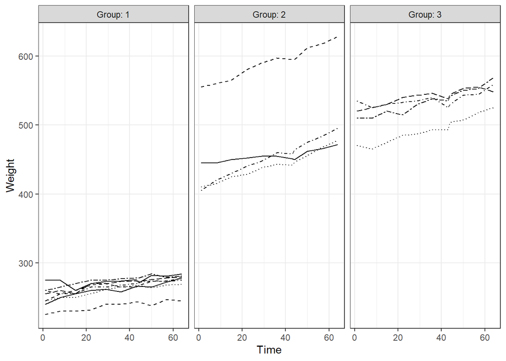

```r
p1 <- ggplot(RATSL, aes(x = Time, y = Weight, linetype = ID))
p2 <- p1 + geom_line() + scale_linetype_manual(values = rep(1:10, times=2))
p3 <- p2 + facet_grid(. ~ Group, labeller = label_both)
p4 <- p3 + theme_bw() + theme(legend.position = "none")
p5 <- p4 + theme(panel.grid.minor.y = element_blank())
p6 <- p5 + scale_y_continuous(limits = c(min(RATSL$Weight), max(RATSL$Weight)))
p6
```

We can see that the rats in Group 1 start (and end) up much lighter than those in Group 2 or 3. Most of the rats appear to gain weight over time.

One rat in Group 2 looks like bit of an outlier, being much heavier than the other rats.

Let’s standardize the weights (grouped by group and time) and look again.

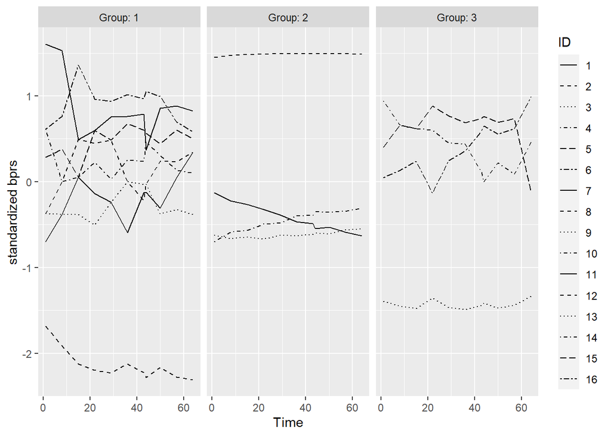

```r
RATSL <- RATSL %>%
  group_by(Time, Group) %>%
  mutate( stdbprs = (Weight - mean(Weight))/sd(Weight) ) %>%
  ungroup()


ggplot(RATSL, aes(x = Time, y = stdbprs, linetype = ID)) +
  geom_line() +
  scale_linetype_manual(values = rep(1:10, times=2)) +
  facet_grid(. ~ Group, labeller = label_both) +
  scale_y_continuous(name = "standardized bprs")
```

Hmmm… there doesn’t appear to be any major shifts between the rats.

Now let’s do a mean weight development for the three group of rats.

```r
n <- RATSL$Time %>% unique() %>% length()

RATSS <- RATSL %>%
  group_by(Group, Time) %>%
  summarise( mean=mean(Weight), se=sd(Weight)/sqrt(length(unique(Time))) ) %>%
  ungroup()
```

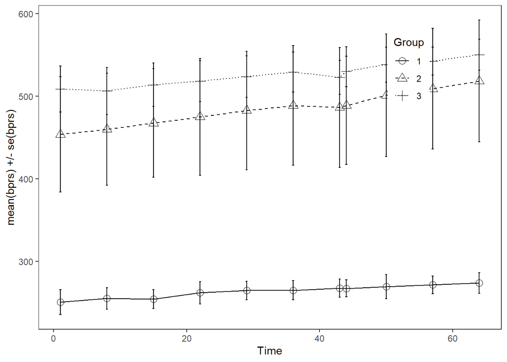

```r
p1 <- ggplot(RATSS, aes(x = Time, y = mean, linetype = Group, shape = Group))
p2 <- p1 + geom_line() + scale_linetype_manual(values = c(1,2,3))
p3 <- p2 + geom_point(size=3) + scale_shape_manual(values = c(1,2,3))
p4 <- p3 + geom_errorbar(aes(ymin=mean-se, ymax=mean+se, linetype="1"), width=0.3)
p5 <- p4 + theme_bw() + theme(panel.grid.major = element_blank(), panel.grid.minor = element_blank())
p6 <- p5 + theme(legend.position = c(0.8,0.8))
p7 <- p6 + scale_y_continuous(name = "mean(bprs) +/- se(bprs)")
p7
```

All three groups on average appear to gain a little bit of weight. Group 2 and 3 perhaps more so than group 1.

Let’s do some boxplots.

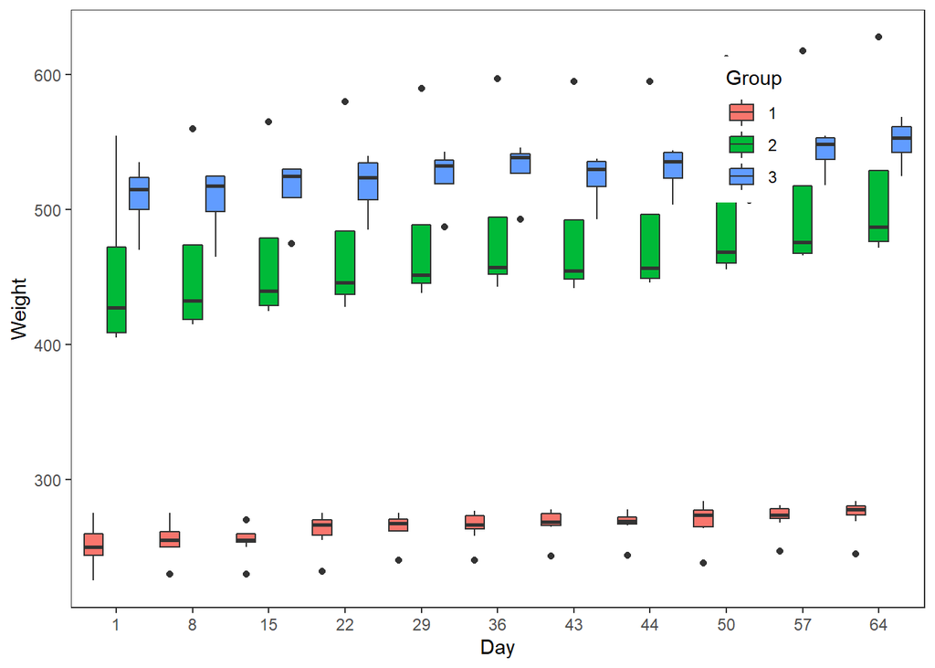

```r
p1 <- ggplot(RATSL, aes(x = factor(Time), y = Weight, fill = Group))
p2 <- p1 + geom_boxplot(position = position_dodge(width = 0.9))
p3 <- p2 + theme_bw() + theme(panel.grid.major = element_blank(), panel.grid.minor = element_blank())
p4 <- p3 + theme(legend.position = c(0.8,0.8))
p5 <- p4 + scale_x_discrete(name = "Day")
p5
```

```r
RATSS2 <- RATSL %>%
  filter(Time > 1) %>%
  group_by(Group, ID) %>%
  summarise( mean=mean(Weight) ) %>%
  ungroup()

glimpse(RATSS2)
```

```
## Rows: 16
## Columns: 3
## $ Group <fct> 1, 1, 1, 1, 1, 1, 1, 1, 2, 2, 2, 2, 3, 3, 3, 3
## $ ID    <fct> 1, 2, 3, 4, 5, 6, 7, 8, 9, 10, 11, 12, 13, 14, 15, 16
## $ mean  <dbl> 263.2, 238.9, 261.7, 267.2, 270.9, 276.2, 274.6, 267.5, 443.9...
```

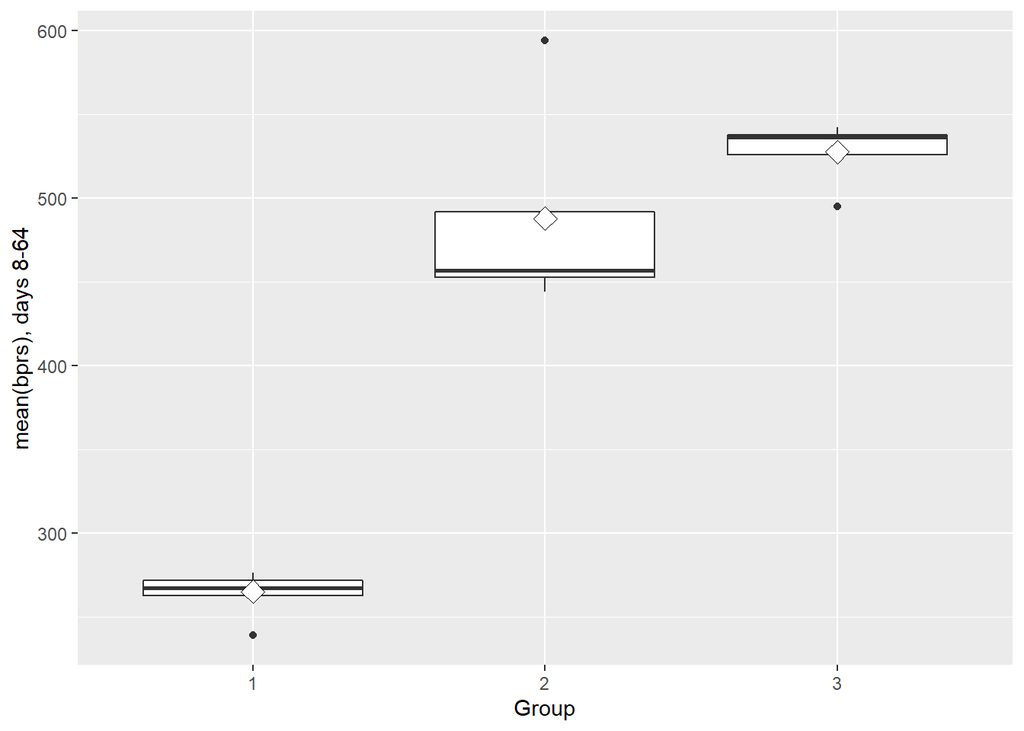

```r
ggplot(RATSS2, aes(x = Group, y = mean)) +
  geom_boxplot() +
  stat_summary(fun.y = "mean", geom = "point", shape=23, size=4, fill = "white") +
  scale_y_continuous(name = "mean(bprs), days 8-64")
```

It was a bit hard to make out before but here we can see that rats from group 3 are in fact on average a bit heavier than those from group 2 (group 1 is of course by far the lightest). We can also see a big outlier in group 2 (almost certianly the heavy rat we saw before). Let’s remove it.

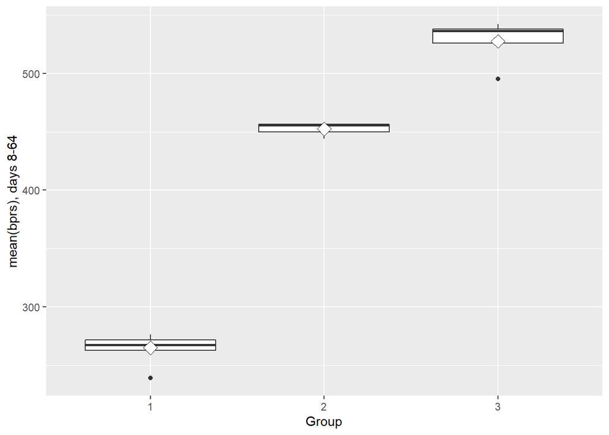

```r
RATSL_Filt <- RATSS2 %>%
  filter(mean < 580)


ggplot(RATSL_Filt, aes(x = Group, y = mean)) +
  geom_boxplot() +
  stat_summary(fun.y = "mean", geom = "point", shape=23, size=4, fill = "white") +
  scale_y_continuous(name = "mean(bprs), days 8-64")
```

Gone!

Alright, now let’s do some testing with ANOVA.

```r
#read the original data and remove the outlier rat
RATS_o <-  read.csv("data/rats.csv")
RATS_o <- RATS_o %>%
  filter(ID != 12)

#now let's add the first day values as a baseline variable
RATSL_Filt2 <- RATSL_Filt %>%
  mutate(baseline = RATS_o$WD1)
fit <- lm(mean ~ baseline + Group, data = RATSL_Filt2)
anova(fit)
```

```
## Analysis of Variance Table
##
## Response: mean
##           Df Sum Sq Mean Sq   F value    Pr(>F)
## baseline   1 207817  207817 2714.9357 1.601e-14 ***
## Group      2   1483     742    9.6878  0.003748 **
## Residuals 11    842      77
## ---
## Signif. codes:  0 '***' 0.001 '**' 0.01 '*' 0.05 '.' 0.1 ' ' 1
```

Hmm… we can see from the ANOVA that there are indeed statistically significant differences between the groups (p = 0.004).

## 6.2 BPRS analysis

Let’s load up (and factor the categorical variables) and look at the dataset.

```r
BPRSL <- read.csv("./data/bprsL.csv")

BPRSL$subject <- factor(BPRSL$subject)
BPRSL$treatment <- factor(BPRSL$treatment)

glimpse(BPRSL)
```

```
## Rows: 360
## Columns: 5
## $ treatment <fct> 1, 1, 1, 1, 1, 1, 1, 1, 1, 1, 1, 1, 1, 1, 1, 1, 1, 1, 1, ...
## $ subject   <fct> 1, 2, 3, 4, 5, 6, 7, 8, 9, 10, 11, 12, 13, 14, 15, 16, 17...
## $ weeks     <chr> "week0", "week0", "week0", "week0", "week0", "week0", "we...
## $ bprs      <int> 42, 58, 54, 55, 72, 48, 71, 30, 41, 57, 30, 55, 36, 38, 6...
## $ week      <int> 0, 0, 0, 0, 0, 0, 0, 0, 0, 0, 0, 0, 0, 0, 0, 0, 0, 0, 0, ...
```

The data describes 40 male subjects who were assigned to two different treatment groups. They were measures on a brief psychiatric rating scale (BPRS) on a weekly basis for 8 weeks (+ a measurement at the start). BPRS measures symptoms such as hostility, hallucinations and suspiciousness.

Let’s do some plotting.

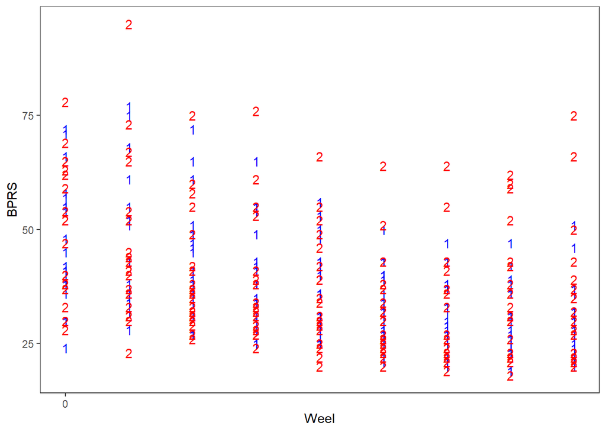

```r
p1 <- ggplot(BPRSL, aes(x = week, y = bprs, group = subject))
p2 <- p1 + geom_text(aes(label = treatment), color = c("blue", 'red')[BPRSL$treatment])
p3 <- p2 + scale_x_continuous(name = "Weel", breaks = seq(0, 60, 10))
p4 <- p3 + scale_y_continuous(name = "BPRS")
p5 <- p4 + theme_bw()
p6 <- p5 + theme(panel.grid.major = element_blank(), panel.grid.minor = element_blank())
p6
```

This is a bit hard to make out. Doesn’t seem to be any obvious difference between the groups. Treatment 2 gets the top value every week but this could be due to a single participant with particularly high bprs values.

Let’s check individual response profiles.

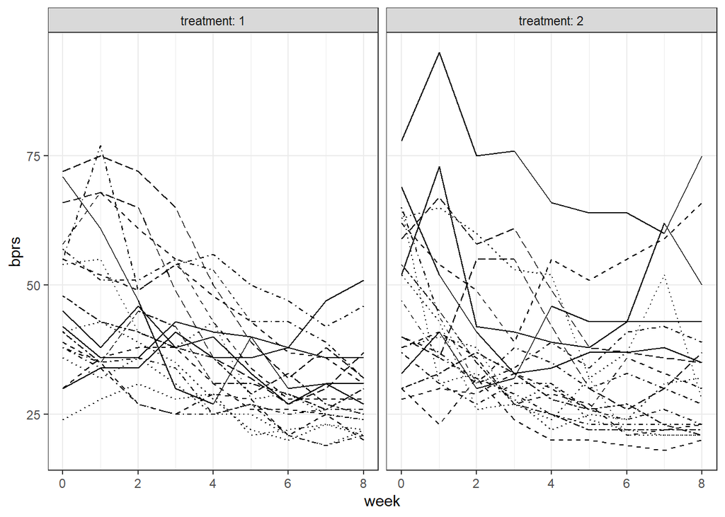

```r
p1 <- ggplot(BPRSL, aes(x = week, y = bprs, linetype = subject))
p2 <- p1 + geom_line() + scale_linetype_manual(values = rep(1:10, times=2))
p3 <- p2 + facet_grid(. ~ treatment, labeller = label_both)
p4 <- p3 + theme_bw() + theme(legend.position = "none")
p5 <- p4 + theme(panel.grid.minor.y = element_blank())
p6 <- p5 + scale_y_continuous(limits = c(min(BPRSL$bprs), max(BPRSL$bprs)))
p6
```

Looks like the bprs scores tend to go down with time. Hard to see any differences with the groups (other than one participant in treatment group 2 having rather high scores compared to others).

Let’s fit a simple linear regression model with bprs as response variable and week and treatment as explanatory variables (ignoring the repeated-measures structure for now).

```r
BPRSL_Reg <- lm(bprs ~ week + treatment, data = BPRSL)
summary(BPRSL_Reg)
```

```
##
## Call:
## lm(formula = bprs ~ week + treatment, data = BPRSL)
##
## Residuals:
##     Min      1Q  Median      3Q     Max
## -22.454  -8.965  -3.196   7.002  50.244
##
## Coefficients:
##             Estimate Std. Error t value Pr(>|t|)
## (Intercept)  46.4539     1.3670  33.982   <2e-16 ***
## week         -2.2704     0.2524  -8.995   <2e-16 ***
## treatment2    0.5722     1.3034   0.439    0.661
## ---
## Signif. codes:  0 '***' 0.001 '**' 0.01 '*' 0.05 '.' 0.1 ' ' 1
##
## Residual standard error: 12.37 on 357 degrees of freedom
## Multiple R-squared:  0.1851, Adjusted R-squared:  0.1806
## F-statistic: 40.55 on 2 and 357 DF,  p-value: < 2.2e-16
```

We can see that week has a significant effect, but treatment doesn’t. Now let’s fit a random intercept model with subject as random effect.

```r
library("lme4")
library("afex")

BPRSL_Ref <- lmer(bprs ~ week + treatment + (1 | subject), data = BPRSL, REML = FALSE)
summary(BPRSL_Ref)
```

```
## Linear mixed model fit by maximum likelihood . t-tests use Satterthwaite's
##   method [lmerModLmerTest]
## Formula: bprs ~ week + treatment + (1 | subject)
##    Data: BPRSL
##
##      AIC      BIC   logLik deviance df.resid
##   2748.7   2768.1  -1369.4   2738.7      355
##
## Scaled residuals:
##     Min      1Q  Median      3Q     Max
## -3.0481 -0.6749 -0.1361  0.4813  3.4855
##
## Random effects:
##  Groups   Name        Variance Std.Dev.
##  subject  (Intercept)  47.41    6.885
##  Residual             104.21   10.208
## Number of obs: 360, groups:  subject, 20
##
## Fixed effects:
##             Estimate Std. Error       df t value Pr(>|t|)
## (Intercept)  46.4539     1.9090  37.2392  24.334   <2e-16 ***
## week         -2.2704     0.2084 340.0000 -10.896   <2e-16 ***
## treatment2    0.5722     1.0761 340.0000   0.532    0.595
## ---
## Signif. codes:  0 '***' 0.001 '**' 0.01 '*' 0.05 '.' 0.1 ' ' 1
##
## Correlation of Fixed Effects:
##            (Intr) week
## week       -0.437
## treatment2 -0.282  0.000
```

We can see that only week has a significant effect (bpsr scores drop as week increases).

Now, let’s also fit a random intercept and random slope model.

```r
BPRSL_Ref1 <- lmer(bprs ~ week + treatment + (treatment | subject), data = BPRSL, REML = FALSE)
summary(BPRSL_Ref1)
```

```
## Linear mixed model fit by maximum likelihood . t-tests use Satterthwaite's
##   method [lmerModLmerTest]
## Formula: bprs ~ week + treatment + (treatment | subject)
##    Data: BPRSL
##
##      AIC      BIC   logLik deviance df.resid
##   2584.7   2611.9  -1285.4   2570.7      353
##
## Scaled residuals:
##     Min      1Q  Median      3Q     Max
## -2.3048 -0.6022 -0.0652  0.4414  3.1690
##
## Random effects:
##  Groups   Name        Variance Std.Dev. Corr
##  subject  (Intercept)  64.42    8.026
##           treatment2  188.83   13.742   -0.56
##  Residual              54.23    7.364
## Number of obs: 360, groups:  subject, 20
##
## Fixed effects:
##             Estimate Std. Error       df t value Pr(>|t|)
## (Intercept)  46.4539     1.9708  24.3001  23.571   <2e-16 ***
## week         -2.2704     0.1503 320.0001 -15.104   <2e-16 ***
## treatment2    0.5722     3.1692  19.9999   0.181    0.859
## ---
## Signif. codes:  0 '***' 0.001 '**' 0.01 '*' 0.05 '.' 0.1 ' ' 1
##
## Correlation of Fixed Effects:
##            (Intr) week
## week       -0.305
## treatment2 -0.540  0.000
```

Same as before.

And a random intercept and random Slope Model with interaction between treatment and week.

```r
BPRSL_Ref2 <- lmer(bprs ~ week * treatment + (treatment | subject), data = BPRSL, REML = FALSE)
summary(BPRSL_Ref2)
```

```
## Linear mixed model fit by maximum likelihood . t-tests use Satterthwaite's
##   method [lmerModLmerTest]
## Formula: bprs ~ week * treatment + (treatment | subject)
##    Data: BPRSL
##
##      AIC      BIC   logLik deviance df.resid
##   2581.0   2612.1  -1282.5   2565.0      352
##
## Scaled residuals:
##     Min      1Q  Median      3Q     Max
## -2.2782 -0.6037 -0.0797  0.4437  3.3942
##
## Random effects:
##  Groups   Name        Variance Std.Dev. Corr
##  subject  (Intercept)  64.53    8.033
##           treatment2  189.04   13.749   -0.56
##  Residual              53.27    7.298
## Number of obs: 360, groups:  subject, 20
##
## Fixed effects:
##                 Estimate Std. Error       df t value Pr(>|t|)
## (Intercept)      47.8856     2.0573  28.8053  23.275   <2e-16 ***
## week             -2.6283     0.2107 319.9999 -12.475   <2e-16 ***
## treatment2       -2.2911     3.3859  26.0248  -0.677   0.5046
## week:treatment2   0.7158     0.2980 319.9999   2.402   0.0169 *
## ---
## Signif. codes:  0 '***' 0.001 '**' 0.01 '*' 0.05 '.' 0.1 ' ' 1
##
## Correlation of Fixed Effects:
##             (Intr) week   trtmn2
## week        -0.410
## treatment2  -0.586  0.249
## wek:trtmnt2  0.290 -0.707 -0.352
```

This model suggests there’s a positive interaction between week and treatment, in addition to the negative effect of week.

Now, let’s compare the models.

```r
anova(BPRSL_Ref, BPRSL_Ref1)
```

```
## Data: BPRSL
## Models:
## BPRSL_Ref: bprs ~ week + treatment + (1 | subject)
## BPRSL_Ref1: bprs ~ week + treatment + (treatment | subject)
##            npar    AIC    BIC  logLik deviance  Chisq Df Pr(>Chisq)
## BPRSL_Ref     5 2748.7 2768.1 -1369.4   2738.7
## BPRSL_Ref1    7 2584.7 2611.9 -1285.4   2570.7 167.97  2  < 2.2e-16 ***
## ---
## Signif. codes:  0 '***' 0.001 '**' 0.01 '*' 0.05 '.' 0.1 ' ' 1
```

```r
anova(BPRSL_Ref1, BPRSL_Ref2)
```

```
## Data: BPRSL
## Models:
## BPRSL_Ref1: bprs ~ week + treatment + (treatment | subject)
## BPRSL_Ref2: bprs ~ week * treatment + (treatment | subject)
##            npar    AIC    BIC  logLik deviance  Chisq Df Pr(>Chisq)
## BPRSL_Ref1    7 2584.7 2611.9 -1285.4   2570.7
## BPRSL_Ref2    8 2581.0 2612.1 -1282.5   2565.0 5.7203  1    0.01677 *
## ---
## Signif. codes:  0 '***' 0.001 '**' 0.01 '*' 0.05 '.' 0.1 ' ' 1
```

```r
anova(BPRSL_Ref,BPRSL_Ref2)
```

```
## Data: BPRSL
## Models:
## BPRSL_Ref: bprs ~ week + treatment + (1 | subject)
## BPRSL_Ref2: bprs ~ week * treatment + (treatment | subject)
##            npar    AIC    BIC  logLik deviance  Chisq Df Pr(>Chisq)
## BPRSL_Ref     5 2748.7 2768.1 -1369.4   2738.7
## BPRSL_Ref2    8 2581.0 2612.1 -1282.5   2565.0 173.69  3  < 2.2e-16 ***
## ---
## Signif. codes:  0 '***' 0.001 '**' 0.01 '*' 0.05 '.' 0.1 ' ' 1
```

Based on both the p-values and the [AIC](https://en.wikipedia.org/wiki/Akaike_information_criterion) estimator, BPRSL_Ref2 (one with the interaction) appears to perform the best (about the same as BPRSL_Ref1).

Let’s also look at the fitted values and how they look against the observed values (which we already plotted before).

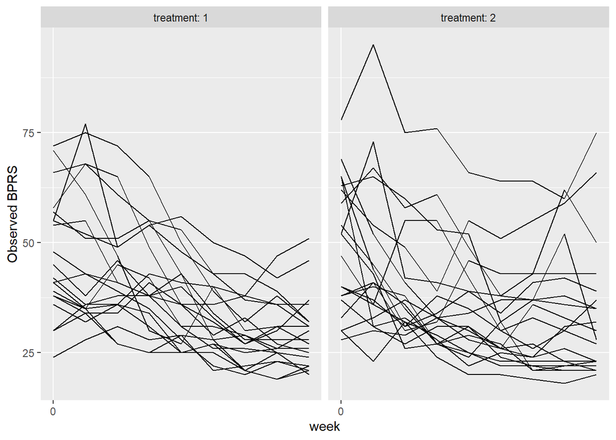

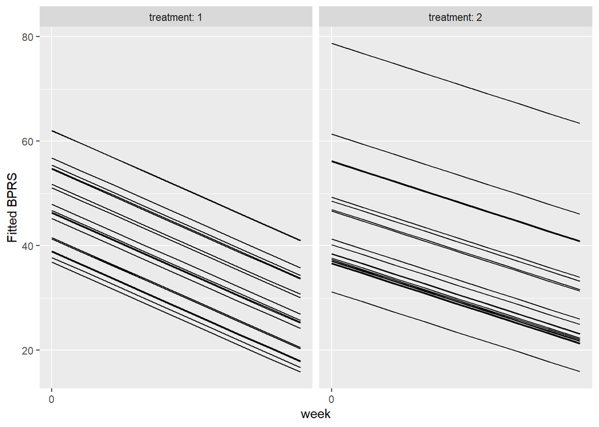